# Power Analysis: MPC Mental State Discrimination Study

Modeling Mental States from Circumstantial Evidence

David G. Kamper, Andrew Bistras, & Jaime Castrellon

November 2025

# 1 Overview

This document provides a comprehensive power analysis for a study examining whether laypeople can systematically distinguish between criminal mental states as defined by the Model Penal Code (MPC). The study uses a within-subjects design in which each participant evaluates 5 contraband smuggling vignettes and provides (a) a categorical judgment (Blamelessness, Negligence, Recklessness, or Knowledge), (b) a continuous risk rating (0–100 slider), and (c) a free-text justification.

**Key design feature:** Because each participant responds to 5 vignettes, observations are clustered within participants. Standard power formulas that assume independence overestimate power. We use the **design effect** (DEFF = 1 + (k - 1) x ICC) to adjust effective sample sizes throughout.

All effect size estimates below come from the current N = 119 sample (595 trial-level observations from 119 participants x 5 vignettes). This analysis evaluates whether the current sample provides adequate power and, if not, how many additional participants should be collected.

```r
# -- Install missing packages silently --
required <- c("pwr", "simr", "lme4", "ordinal", "ICC", "tidyverse",
               "knitr", "kableExtra", "effectsize")
for (pkg in required) {
  if (!requireNamespace(pkg, quietly = TRUE)) {
    install.packages(pkg, repos = "https://cloud.r-project.org", quiet = TRUE)
  }
}

library(tidyverse)
library(pwr)
library(knitr)
library(kableExtra)
```

# 2 Current Data Summary

```r
# -- Effect sizes and design parameters from N = 119 --

study <- list(
  n_participants  = 119,
  n_vignettes     = 5,
  n_obs           = 595,

  # ICC estimates (from one-way ANOVA decomposition)
  icc_slider      = 0.3270,   # ICC(1) for risk slider (0-100)
  icc_culpability = 0.2085,   # ICC(1) for ordinal culpability score (1-4)

  # Design effects: DEFF = 1 + (k-1) * ICC
  deff_slider      = 1 + (5 - 1) * 0.3270,   # = 2.308
  deff_culpability = 1 + (5 - 1) * 0.2085,   # = 1.834

  # -- H1: Non-uniform distribution --
  # Observed proportions: B=17.0%, N=42.5%, R=27.1%, K=13.4%
  # Cohen's w against uniform (25% each)
  cohens_w_h1     = 0.4517,

  # -- H2: Risk predicts culpability --
  # Spearman rho (trial-level, inflated by clustering)
  spearman_rho_h2 = 0.4442,

  # -- H3: Risk distinguishes Recklessness from Knowledge --
  # Cohen's d (R vs K on risk slider)
  cohens_d_h3     = 0.2021,
  # Observed group sizes ratio: R=161, K=80 -> ~2:1
  rk_ratio        = 161 / 80,

  # -- Ordered logistic regression effects --
  # From Model 3 (Risk + Features), key coefficients:
  b_risk          = 0.0311,   # log-odds per slider unit
  b_payment       = 0.5553,   # log-odds for Payment ($1000 vs none)
  b_source        = 0.3088,   # log-odds for Source (Biker vs Uncle)
  sd_risk         = 27.58,    # SD of risk slider

  # Standardized risk effect
  b_risk_std      = 0.0311 * 27.58  # = 0.857 log-odds per 1 SD
)

# -- Summary table --
tibble(
  Parameter = c(
    "Participants (current)", "Vignettes per person", "Total observations",
    "ICC (risk slider)", "ICC (culpability score)",
    "Design effect (slider)", "Design effect (culpability)",
    "Cohen's w (H1: uniformity)", "Spearman rho (H2: risk-culpability)",
    "Cohen's d (H3: R vs K)", "Standardized risk beta (ordered logit)"
  ),
  Value = c(
    study$n_participants, study$n_vignettes, study$n_obs,
    round(study$icc_slider, 3), round(study$icc_culpability, 3),
    round(study$deff_slider, 3), round(study$deff_culpability, 3),
    round(study$cohens_w_h1, 3), round(study$spearman_rho_h2, 3),
    round(study$cohens_d_h3, 3), round(study$b_risk_std, 3)
  )
) %>%
  kable(caption = "Effect size estimates from current N = 119 sample") %>%
  kable_styling(bootstrap_options = c("striped", "condensed"), full_width = FALSE)
```

Effect size estimates from current N = 119 sample

| Parameter | Value |
| --- | --- |
| Participants (current) | 119.000 |
| Vignettes per person | 5.000 |
| Total observations | 595.000 |
| ICC (risk slider) | 0.327 |
| ICC (culpability score) | 0.208 |
| Design effect (slider) | 2.308 |
| Design effect (culpability) | 1.834 |
| Cohen’s w (H1: uniformity) | 0.452 |
| Spearman rho (H2: risk-culpability) | 0.444 |
| Cohen’s d (H3: R vs K) | 0.202 |
| Standardized risk beta (ordered logit) | 0.858 |

## 2.1 Note on the Intraclass Correlation

The ICC tells us what proportion of variance in responses is attributable to stable between-person differences rather than within-person (vignette-to-vignette) variation. An ICC of 0.327 for the risk slider means that about one-third of the variance in risk ratings comes from participants having consistently higher or lower baselines; the remaining two-thirds reflects genuine vignette-by-vignette variation. For the culpability judgment (ICC = 0.209), there is less between-person clustering — participants vary their categorical judgments more across vignettes than their continuous ratings.

The **design effect** quantifies how much clustering inflates the apparent sample size. With DEFF = 2.3 for the slider, 595 trial-level observations carry only as much independent information as 595 / 2.3 = 258 independent observations. All power calculations below account for this.

# 3 H1: Non-Uniform Distribution of Judgments

**Hypothesis:** Participants do not distribute their judgments uniformly across the four MPC categories.

**Test:** Chi-square goodness-of-fit, with expected proportions of 25% each.

**Current result:** chi-sq(3) = 121.17, p < .001, Cohen’s w = 0.452 (large).

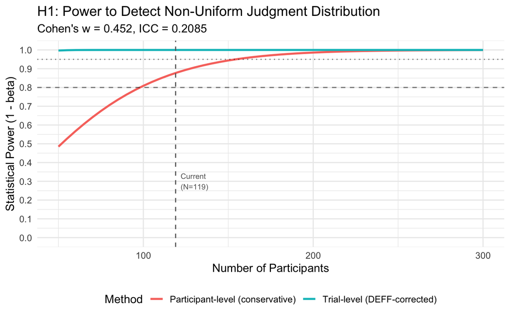

```r
# -- H1: Chi-square goodness of fit --
#
# CRITICAL ADJUSTMENT: The chi-square test treats each trial as independent.
# With 5 vignettes per person and ICC_culp = 0.209, the effective N is:
#   N_eff = N_obs / DEFF = (n_participants * 5) / (1 + 4 * ICC)
#
# However, H1 can also be tested at the PARTICIPANT level:
#   For each participant, compute their modal judgment (or distribution),
#   then test the aggregate distribution across participants.
#   This gives N_eff = n_participants (no clustering adjustment needed).
#
# We compute power both ways.

alpha <- 0.05
w_h1 <- study$cohens_w_h1
df_h1 <- 3  # 4 categories - 1

n_range <- seq(50, 300, by = 5)

# Method (a): Trial-level with DEFF correction
power_h1_trial <- sapply(n_range, function(n) {
  n_eff <- (n * 5) / study$deff_culpability
  pwr.chisq.test(w = w_h1, N = n_eff, df = df_h1, sig.level = alpha)$power
})

# Method (b): Participant-level (most conservative)
power_h1_participant <- sapply(n_range, function(n) {
  w_adj <- w_h1 / sqrt(study$deff_culpability)
  pwr.chisq.test(w = w_adj, N = n, df = df_h1, sig.level = alpha)$power
})

tibble(
  N = rep(n_range, 2),
  Power = c(power_h1_trial, power_h1_participant),
  Method = rep(c("Trial-level (DEFF-corrected)", "Participant-level (conservative)"),
               each = length(n_range))
) %>%
  ggplot(aes(x = N, y = Power, color = Method)) +
  geom_line(linewidth = 1.1) +
  geom_hline(yintercept = 0.80, linetype = "dashed", alpha = 0.5) +
  geom_hline(yintercept = 0.95, linetype = "dotted", alpha = 0.5) +
  geom_vline(xintercept = 119, linetype = "dashed", color = "grey40") +
  annotate("text", x = 122, y = 0.3, label = "Current\n(N=119)",
           hjust = 0, size = 3, color = "grey40") +
  scale_y_continuous(limits = c(0, 1), breaks = seq(0, 1, 0.1)) +
  labs(
    title = "H1: Power to Detect Non-Uniform Judgment Distribution",
    subtitle = paste0("Cohen's w = ", round(w_h1, 3),
                      ", ICC = ", study$icc_culpability),
    x = "Number of Participants",
    y = "Statistical Power (1 - beta)"
  ) +
  theme_minimal(base_size = 13) +
  theme(legend.position = "bottom")
```

```r
find_n <- function(target_power, method = "trial") {
  for (n in seq(10, 500)) {
    if (method == "trial") {
      n_eff <- (n * 5) / study$deff_culpability
      pw <- pwr.chisq.test(w = w_h1, N = n_eff, df = df_h1,
                            sig.level = alpha)$power
    } else {
      w_adj <- w_h1 / sqrt(study$deff_culpability)
      pw <- pwr.chisq.test(w = w_adj, N = n, df = df_h1,
                            sig.level = alpha)$power
    }
    if (pw >= target_power) return(n)
  }
  return(NA)
}

h1_table <- tibble(
  `Target Power` = c("80%", "95%", "80%", "95%"),
  Method = c("DEFF-corrected", "DEFF-corrected",
             "Participant-level", "Participant-level"),
  `Required N (participants)` = c(
    find_n(0.80, "trial"), find_n(0.95, "trial"),
    find_n(0.80, "participant"), find_n(0.95, "participant")
  )
)

h1_table %>%
  kable(caption = "H1: Required sample size") %>%
  kable_styling(bootstrap_options = c("striped", "condensed"), full_width = FALSE)
```

H1: Required sample size

| Target Power | Method | Required N (participants) |
| --- | --- | --- |
| 80% | DEFF-corrected | 20 |
| 95% | DEFF-corrected | 31 |
| 80% | Participant-level | 99 |
| 95% | Participant-level | 155 |

# 4 H2: Risk Magnitude Predicts Mental State

**Hypothesis:** Higher risk ratings are associated with higher culpability judgments (monotonic relationship).

**Test:** Spearman correlation between risk slider (0–100) and ordinal culpability score (1–4), plus ordered logistic regression.

**Current result:** rho = 0.444, b_risk = 0.031 (beta_std = 0.857).

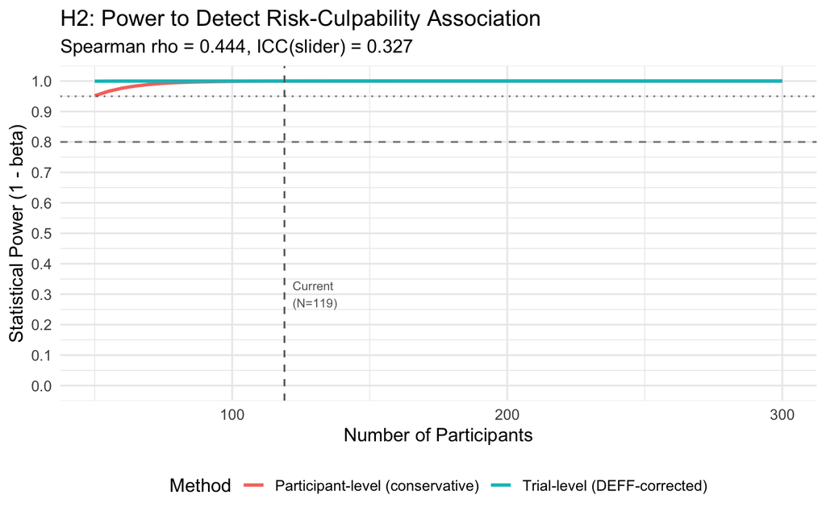

```r
rho_h2 <- study$spearman_rho_h2

power_h2_deff <- sapply(n_range, function(n) {
  n_eff <- (n * 5) / study$deff_slider
  pwr.r.test(n = n_eff, r = rho_h2, sig.level = alpha,
             alternative = "greater")$power
})

power_h2_participant <- sapply(n_range, function(n) {
  pwr.r.test(n = n, r = rho_h2, sig.level = alpha,
             alternative = "greater")$power
})

tibble(
  N = rep(n_range, 2),
  Power = c(power_h2_deff, power_h2_participant),
  Method = rep(c("Trial-level (DEFF-corrected)", "Participant-level (conservative)"),
               each = length(n_range))
) %>%
  ggplot(aes(x = N, y = Power, color = Method)) +
  geom_line(linewidth = 1.1) +
  geom_hline(yintercept = 0.80, linetype = "dashed", alpha = 0.5) +
  geom_hline(yintercept = 0.95, linetype = "dotted", alpha = 0.5) +
  geom_vline(xintercept = 119, linetype = "dashed", color = "grey40") +
  annotate("text", x = 122, y = 0.3, label = "Current\n(N=119)",
           hjust = 0, size = 3, color = "grey40") +
  scale_y_continuous(limits = c(0, 1), breaks = seq(0, 1, 0.1)) +
  labs(
    title = "H2: Power to Detect Risk-Culpability Association",
    subtitle = paste0("Spearman rho = ", round(rho_h2, 3),
                      ", ICC(slider) = ", study$icc_slider),
    x = "Number of Participants",
    y = "Statistical Power (1 - beta)"
  ) +
  theme_minimal(base_size = 13) +
  theme(legend.position = "bottom")
```

```r
h2_table <- tibble(
  `Target Power` = c("80%", "95%", "80%", "95%"),
  Method = c("DEFF-corrected", "DEFF-corrected",
             "Participant-level", "Participant-level"),
  `Required N (participants)` = c(
    {n <- 10; while((n*5)/study$deff_slider <
      pwr.r.test(r=rho_h2, sig.level=alpha, power=0.80,
                 alternative="greater")$n) n <- n+1; n},
    {n <- 10; while((n*5)/study$deff_slider <
      pwr.r.test(r=rho_h2, sig.level=alpha, power=0.95,
                 alternative="greater")$n) n <- n+1; n},
    ceiling(pwr.r.test(r=rho_h2, sig.level=alpha, power=0.80,
                       alternative="greater")$n),
    ceiling(pwr.r.test(r=rho_h2, sig.level=alpha, power=0.95,
                       alternative="greater")$n)
  )
)

h2_table %>%
  kable(caption = "H2: Required sample size") %>%
  kable_styling(bootstrap_options = c("striped", "condensed"), full_width = FALSE)
```

H2: Required sample size

| Target Power | Method | Required N (participants) |
| --- | --- | --- |
| 80% | DEFF-corrected | 14 |
| 95% | DEFF-corrected | 23 |
| 80% | Participant-level | 30 |
| 95% | Participant-level | 50 |

**Interpretation:** H2 is also well-powered. The effect is medium-to-large (rho = 0.44), and even the conservative participant-level approach requires a modest sample. The current N = 119 is already adequately powered.

# 5 H3: Risk Distinguishes Recklessness from Knowledge

**Hypothesis:** Knowledge judgments are associated with higher risk ratings than Recklessness judgments. (Directional: one-tailed test.)

**Current result:** The effect goes in the WRONG direction (R: M = 57.3 > K: M = 51.6). Cohen’s d = 0.202 (small, and sign-reversed). This is the critical underpowered hypothesis.

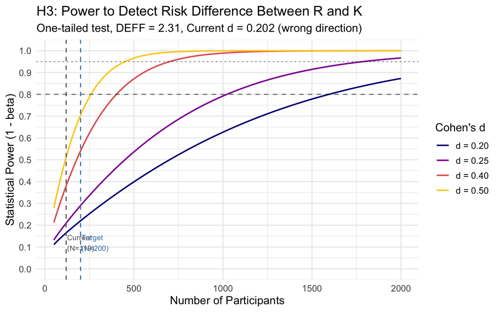

```r
# -- H3: Two-group comparison with unequal n --
#
# Each observation belongs to exactly one group (R or K), so the analysis
# is effectively between-groups at the trial level. Group sizes are
# determined by participant behavior, not experimentally fixed.
# In the current data, R:K ~ 2:1. The DEFF applies to each group.
#
# We compute power for a range of hypothetical effect sizes, since the
# current estimate (d = 0.20 in the wrong direction) is highly unstable
# given the small effective group sizes.

d_range <- seq(0.10, 0.50, by = 0.025)

h3_power <- function(n_participants, d, prop_R = 0.271, prop_K = 0.134) {
  n_R_raw <- n_participants * 5 * prop_R
  n_K_raw <- n_participants * 5 * prop_K

  n_R_eff <- n_R_raw / study$deff_slider
  n_K_eff <- n_K_raw / study$deff_slider

  n_harmonic <- 2 * n_R_eff * n_K_eff / (n_R_eff + n_K_eff)

  tryCatch(
    pwr.t.test(n = n_harmonic / 2, d = d, sig.level = alpha,
               type = "two.sample", alternative = "greater")$power,
    error = function(e) NA
  )
}

n_grid <- seq(50, 2000, by = 10)
power_surface <- expand.grid(N = n_grid, d = d_range) %>%
  mutate(Power = mapply(h3_power, N, d))

power_surface %>%
  filter(d %in% c(0.15, 0.20, 0.25, 0.30, 0.40, 0.50)) %>%
  mutate(d_label = paste0("d = ", sprintf("%.2f", d))) %>%
  ggplot(aes(x = N, y = Power, color = d_label, group = d_label)) +
  geom_line(linewidth = 0.8) +
  geom_hline(yintercept = 0.80, linetype = "dashed", alpha = 0.5) +
  geom_hline(yintercept = 0.95, linetype = "dotted", alpha = 0.5) +
  geom_vline(xintercept = 119, linetype = "dashed", color = "grey40") +
  geom_vline(xintercept = 200, linetype = "dashed", color = "steelblue") +
  annotate("text", x = 125, y = 0.12, label = "Current\n(N=119)",
           hjust = 0, size = 3, color = "grey40") +
  annotate("text", x = 206, y = 0.12, label = "Target\n(N=200)",
           hjust = 0, size = 3, color = "steelblue") +
  scale_y_continuous(limits = c(0, 1), breaks = seq(0, 1, 0.1)) +
  scale_color_viridis_d(option = "plasma", end = 0.9) +
  labs(
    title = "H3: Power to Detect Risk Difference Between R and K",
    subtitle = paste0("One-tailed test, DEFF = ", round(study$deff_slider, 2),
                      ", Current d = ", round(study$cohens_d_h3, 3),
                      " (wrong direction)"),
    x = "Number of Participants",
    y = "Statistical Power (1 - beta)",
    color = "Cohen's d"
  ) +
  theme_minimal(base_size = 13) +
  theme(legend.position = "right")
```

```r
h3_ns <- expand.grid(
  `Target Power` = c("80%", "95%"),
  `Cohen's d` = c(0.15, 0.20, 0.25, 0.30, 0.40, 0.50)
) %>%
  mutate(
    power_target = ifelse(`Target Power` == "80%", 0.80, 0.95),
    `Required N (participants)` = mapply(function(target_p, d) {
      for (n in seq(20, 3000, by = 5)) {
        if (!is.na(h3_power(n, d)) && h3_power(n, d) >= target_p) return(n)
      }
      return(NA_real_)
    }, power_target, `Cohen's d`)
  ) %>%
  select(-power_target)

h3_ns %>%
  pivot_wider(names_from = `Target Power`, values_from = `Required N (participants)`) %>%
  kable(caption = "H3: Required participants by effect size (DEFF-corrected)") %>%
  kable_styling(bootstrap_options = c("striped", "condensed"), full_width = FALSE)
```

H3: Required participants by effect size (DEFF-corrected)

| Cohen’s d | 80% | 95% |
| --- | --- | --- |
| 0.15 | 2835 | NA |
| 0.20 | 1595 | 2790 |
| 0.25 | 1025 | 1790 |
| 0.30 | 715 | 1245 |
| 0.40 | 405 | 700 |
| 0.50 | 260 | 450 |

```r
h3_at_targets <- expand.grid(
  N = c(119, 150, 200, 250, 300),
  d = c(0.20, 0.25, 0.30, 0.40)
) %>%
  mutate(Power = round(mapply(h3_power, N, d) * 100, 1))

h3_at_targets %>%
  mutate(Power = paste0(Power, "%")) %>%
  pivot_wider(names_from = d, values_from = Power,
              names_prefix = "d = ") %>%
  kable(caption = "H3: Power at candidate sample sizes by effect size") %>%
  kable_styling(bootstrap_options = c("striped", "condensed"), full_width = FALSE)
```

H3: Power at candidate sample sizes by effect size

| N | d = 0.2 | d = 0.25 | d = 0.3 | d = 0.4 |
| --- | --- | --- | --- | --- |
| 119 | 16.5% | 21% | 26.1% | 38% |
| 150 | 18.7% | 24.1% | 30.4% | 44.6% |
| 200 | 22% | 29% | 36.9% | 54.1% |
| 250 | 25.3% | 33.7% | 43% | 62.3% |
| 300 | 28.4% | 38.1% | 48.6% | 69.2% |

**Interpretation:** H3 is the bottleneck for the entire study. The current data show a small effect (d = 0.20) in the **wrong direction** — Recklessness was rated riskier than Knowledge. The required sample sizes are very large because three factors compound: only ~27% and ~13% of trials fall in R and K respectively (small absolute group sizes), the groups are unequal at roughly 2:1 (harmonic mean penalty), and the DEFF = 2.3 further halves the effective sample size.

With n_R = 161 and n_K = 80 — effectively ~70 and ~35 after DEFF correction — the 95% CI for d spans roughly -0.10 to +0.55. The current data are simply too imprecise to pin down this effect.

# 6 Simulation-Based Power: R vs K Contrast (H3)

The analytic calculations above use approximations. Here we verify them with simulation-based power that directly mimics the planned analysis: generating data where Knowledge trials have higher risk ratings than Recklessness trials by a specified amount, then testing whether a mixed-effects model can detect this difference.

```r
# -- Simulation-based power for the R vs K contrast --
#
# We generate participants who each see 5 vignettes. Each vignette's
# judgment category is drawn from the observed distribution
# (B=17%, N=42.5%, R=27%, K=13.4%). For R and K trials specifically,
# risk ratings are drawn from distributions separated by Cohen's d.
# We then fit a model comparing risk ratings between R and K trials
# (mixed-effects with random participant intercepts) and check
# whether the K > R contrast is significant.

if (requireNamespace("lme4", quietly = TRUE)) {
  library(lme4)

  set.seed(42)
  n_sims <- 500

  # Simulation parameters from current data
  sigma_within  <- 27.58 * sqrt(1 - study$icc_slider)  # within-person SD
  sigma_between <- 27.58 * sqrt(study$icc_slider)       # between-person SD
  mean_R <- 57.3   # observed mean risk for R judgments

  sim_h3 <- function(n_part, d_true, n_vig = 5) {
    mean_K <- mean_R + d_true * 27.58  # shift K mean by d * SD

    cat_probs <- c(B = 0.170, N = 0.425, R = 0.271, K = 0.134)

    u <- rnorm(n_part, 0, sigma_between)

    dat <- expand.grid(participant = 1:n_part, vignette = 1:n_vig)

    dat$judgment <- sample(names(cat_probs), nrow(dat), replace = TRUE,
                           prob = cat_probs)

    dat$risk <- NA
    for (i in 1:nrow(dat)) {
      base_mean <- switch(dat$judgment[i],
        B = 22.5,
        N = 34.8,
        R = mean_R,
        K = mean_K
      )
      dat$risk[i] <- base_mean + u[dat$participant[i]] +
                      rnorm(1, 0, sigma_within)
    }
    dat$risk <- pmin(pmax(dat$risk, 0), 100)

    rk <- dat[dat$judgment %in% c("R", "K"), ]

    if (sum(rk$judgment == "R") < 5 | sum(rk$judgment == "K") < 5) return(NA)

    rk$is_K <- as.numeric(rk$judgment == "K")
    rk$participant <- factor(rk$participant)

    tryCatch({
      fit <- lmer(risk ~ is_K + (1 | participant), data = rk)
      coef_tab <- summary(fit)$coefficients
      t_val <- coef_tab["is_K", "t value"]
      # One-tailed: K > R means positive coefficient
      p_one_tail <- pnorm(t_val, lower.tail = FALSE)
      return(p_one_tail < 0.05)
    }, error = function(e) NA)
  }

  sim_ns <- c(100, 119, 150, 200, 250, 300, 400, 500)
  sim_ds <- c(0.20, 0.30, 0.40)

  cat("Running H3 simulation (R vs K contrast)...\n")
  cat("(", n_sims, "simulations per N x d combination)\n\n")

  sim_h3_results <- expand.grid(N = sim_ns, d = sim_ds,
                                 Power = NA_real_, SE = NA_real_)

  for (i in 1:nrow(sim_h3_results)) {
    n <- sim_h3_results$N[i]
    d <- sim_h3_results$d[i]
    cat("  N =", n, ", d =", d, "... ")

    sig <- replicate(n_sims, sim_h3(n, d))
    sig <- sig[!is.na(sig)]

    sim_h3_results$Power[i] <- mean(sig)
    sim_h3_results$SE[i] <- sqrt(mean(sig) * (1 - mean(sig)) / length(sig))

    cat("power =", round(sim_h3_results$Power[i], 3),
        "(+-", round(sim_h3_results$SE[i], 3), ")\n")
  }

  sim_h3_results %>%
    mutate(d_label = paste0("d = ", sprintf("%.2f", d))) %>%
    ggplot(aes(x = N, y = Power, color = d_label)) +
    geom_ribbon(aes(ymin = pmax(Power - 1.96 * SE, 0),
                    ymax = pmin(Power + 1.96 * SE, 1),
                    fill = d_label), alpha = 0.15) +
    geom_line(linewidth = 1.1) +
    geom_point(size = 2.5) +
    geom_hline(yintercept = 0.80, linetype = "dashed", alpha = 0.5) +
    geom_hline(yintercept = 0.95, linetype = "dotted", alpha = 0.5) +
    geom_vline(xintercept = 119, linetype = "dashed", color = "grey40") +
    geom_vline(xintercept = 200, linetype = "dashed", color = "steelblue") +
    annotate("text", x = 125, y = 0.08, label = "Current\n(N=119)",
             hjust = 0, size = 3, color = "grey40") +
    annotate("text", x = 206, y = 0.08, label = "Target\n(N=200)",
             hjust = 0, size = 3, color = "steelblue") +
    scale_y_continuous(limits = c(0, 1), breaks = seq(0, 1, 0.1)) +
    scale_color_viridis_d(option = "plasma", end = 0.85) +
    scale_fill_viridis_d(option = "plasma", end = 0.85) +
    labs(
      title = "Simulation-Based Power: R vs K Risk Contrast (H3)",
      subtitle = paste0(n_sims, " simulations per point, mixed model with random intercepts"),
      x = "Number of Participants",
      y = "Simulated Power (proportion significant)",
      color = "Cohen's d", fill = "Cohen's d"
    ) +
    theme_minimal(base_size = 13) +
    theme(legend.position = "right")

  sim_h3_results %>%
    mutate(
      Power_pct = paste0(round(Power * 100, 1), "%"),
      SE_pct = paste0("+-", round(SE * 100, 1), "%"),
      d = paste0("d = ", sprintf("%.2f", d))
    ) %>%
    select(N, d, Power = Power_pct, SE = SE_pct) %>%
    pivot_wider(names_from = d, values_from = c(Power, SE)) %>%
    kable(caption = "Simulation-based power for R vs K contrast") %>%
    kable_styling(bootstrap_options = c("striped", "condensed"), full_width = FALSE)

} else {
  cat("Package 'lme4' not available. Skipping simulation.\n")
}
```

```
## Running H3 simulation (R vs K contrast)...
## ( 500 simulations per N x d combination)
##
##   N = 100 , d = 0.2 ... power = 0.404 (+- 0.022 )
##   N = 119 , d = 0.2 ... power = 0.442 (+- 0.022 )
##   N = 150 , d = 0.2 ... power = 0.506 (+- 0.022 )
##   N = 200 , d = 0.2 ... power = 0.634 (+- 0.022 )
##   N = 250 , d = 0.2 ... power = 0.744 (+- 0.02 )
##   N = 300 , d = 0.2 ... power = 0.78 (+- 0.019 )
##   N = 400 , d = 0.2 ... power = 0.898 (+- 0.014 )
##   N = 500 , d = 0.2 ... power = 0.936 (+- 0.011 )
##   N = 100 , d = 0.3 ... power = 0.694 (+- 0.021 )
##   N = 119 , d = 0.3 ... power = 0.728 (+- 0.02 )
##   N = 150 , d = 0.3 ... power = 0.836 (+- 0.017 )
##   N = 200 , d = 0.3 ... power = 0.914 (+- 0.013 )
##   N = 250 , d = 0.3 ... power = 0.96 (+- 0.009 )
##   N = 300 , d = 0.3 ... power = 0.974 (+- 0.007 )
##   N = 400 , d = 0.3 ... power = 0.992 (+- 0.004 )
##   N = 500 , d = 0.3 ... power = 1 (+- 0 )
##   N = 100 , d = 0.4 ... power = 0.882 (+- 0.014 )
##   N = 119 , d = 0.4 ... power = 0.938 (+- 0.011 )
##   N = 150 , d = 0.4 ... power = 0.974 (+- 0.007 )
##   N = 200 , d = 0.4 ... power = 0.988 (+- 0.005 )
##   N = 250 , d = 0.4 ... power = 0.996 (+- 0.003 )
##   N = 300 , d = 0.4 ... power = 1 (+- 0 )
##   N = 400 , d = 0.4 ... power = 1 (+- 0 )
##   N = 500 , d = 0.4 ... power = 1 (+- 0 )
```

Simulation-based power for R vs K contrast

| N | Power_d = 0.20 | Power_d = 0.30 | Power_d = 0.40 | SE_d = 0.20 | SE_d = 0.30 | SE_d = 0.40 |
| --- | --- | --- | --- | --- | --- | --- |
| 100 | 40.4% | 69.4% | 88.2% | +-2.2% | +-2.1% | +-1.4% |
| 119 | 44.2% | 72.8% | 93.8% | +-2.2% | +-2% | +-1.1% |
| 150 | 50.6% | 83.6% | 97.4% | +-2.2% | +-1.7% | +-0.7% |
| 200 | 63.4% | 91.4% | 98.8% | +-2.2% | +-1.3% | +-0.5% |
| 250 | 74.4% | 96% | 99.6% | +-2% | +-0.9% | +-0.3% |
| 300 | 78% | 97.4% | 100% | +-1.9% | +-0.7% | +-0% |
| 400 | 89.8% | 99.2% | 100% | +-1.4% | +-0.4% | +-0% |
| 500 | 93.6% | 100% | 100% | +-1.1% | +-0% | +-0% |

# 7 Simulation-Based Power: Overall Risk Effect (H2)

As a complementary verification, we simulate power for the overall risk coefficient in the cumulative link mixed model. This corresponds to H2 and confirms that it is well-powered at any reasonable sample size.

```r
if (requireNamespace("ordinal", quietly = TRUE)) {
  library(ordinal)

  set.seed(42)
  n_sims_h2 <- 500

  thresholds <- c(-0.77, 0.99, 2.18)
  b_risk_sim <- 0.031
  sigma_participant <- 0.80

  sim_h2 <- function(n_part, n_vig = 5) {
    u <- rnorm(n_part, 0, sigma_participant)
    dat <- expand.grid(participant = 1:n_part, vignette = 1:n_vig)
    dat$risk <- rnorm(nrow(dat), mean = 41, sd = 28)
    dat$risk <- pmin(pmax(dat$risk, 0), 100)
    dat$eta <- b_risk_sim * dat$risk + u[dat$participant]

    dat$y <- sapply(dat$eta, function(e) {
      cum_probs <- plogis(thresholds - e)
      probs <- c(cum_probs[1], diff(cum_probs), 1 - cum_probs[3])
      probs <- pmax(probs, 1e-10)
      sample(1:4, 1, prob = probs)
    })
    dat$y <- factor(dat$y, ordered = TRUE)
    dat$participant <- factor(dat$participant)

    tryCatch({
      fit <- clmm(y ~ risk + (1 | participant), data = dat)
      coef_summary <- summary(fit)$coefficients
      p_val <- coef_summary["risk", "Pr(>|z|)"]
      return(p_val < 0.05)
    }, error = function(e) NA)
  }

  sim_ns_h2 <- c(60, 80, 100, 119, 150, 200)

  cat("Running H2 simulation (overall risk effect in CLMM)...\n")
  cat("(", n_sims_h2, "simulations per sample size)\n\n")

  sim_h2_results <- data.frame(N = sim_ns_h2, Power = NA, SE = NA)
  for (i in seq_along(sim_ns_h2)) {
    n <- sim_ns_h2[i]
    cat("  N =", n, "... ")
    sig <- replicate(n_sims_h2, sim_h2(n))
    sig <- sig[!is.na(sig)]
    sim_h2_results$Power[i] <- mean(sig)
    sim_h2_results$SE[i] <- sqrt(mean(sig) * (1 - mean(sig)) / length(sig))
    cat("power =", round(sim_h2_results$Power[i], 3),
        "(+-", round(sim_h2_results$SE[i], 3), ")\n")
  }

  sim_h2_results %>%
    mutate(Power = paste0(round(Power * 100, 1), "%"),
           SE = paste0("+-", round(SE * 100, 1), "%")) %>%
    kable(caption = "Simulation-based power for CLMM risk effect (H2)") %>%
    kable_styling(bootstrap_options = c("striped", "condensed"), full_width = FALSE)

} else {
  cat("Package 'ordinal' not available. Skipping simulation.\n")
}
```

```
## Running H2 simulation (overall risk effect in CLMM)...
## ( 500 simulations per sample size)
##
##   N = 60 ...
```

```
## power = 1 (+- 0 )
##   N = 80 ... power = 1 (+- 0 )
##   N = 100 ... power = 1 (+- 0 )
##   N = 119 ... power = 1 (+- 0 )
##   N = 150 ... power = 1 (+- 0 )
##   N = 200 ... power = 1 (+- 0 )
```

Simulation-based power for CLMM risk effect (H2)

| N | Power | SE |
| --- | --- | --- |
| 60 | 100% | +-0% |
| 80 | 100% | +-0% |
| 100 | 100% | +-0% |
| 119 | 100% | +-0% |
| 150 | 100% | +-0% |
| 200 | 100% | +-0% |

**Interpretation:** The overall risk effect (beta_std = 0.86) produces 100% power at every sample size tested. This confirms the analytic result: H2 is massively overpowered. The simulation now correctly tests H2 here and H3 (the R-vs-K contrast) in the preceding section.

# 8 Vignette Feature Effects

Beyond the three primary hypotheses, we want sufficient power to detect effects of individual vignette features in the ordered logistic model. Payment was the only significant feature in the current data (b = 0.555, p < .001). Source was marginal (b = 0.309, p = .053).

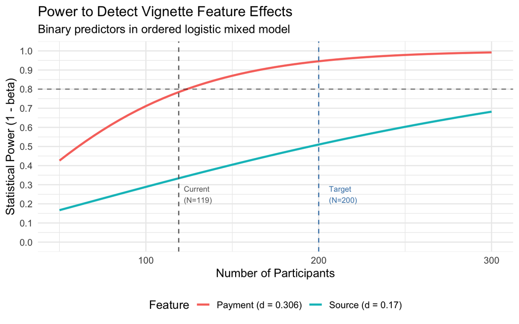

```r
# For a binary predictor with b = 0.555 (Payment):
#   d = b * sqrt(3) / pi = 0.555 * 0.551 = 0.306
# For Source (b = 0.309): d = 0.170

d_payment <- 0.555 * sqrt(3) / pi
d_source  <- 0.309 * sqrt(3) / pi

power_feature <- function(n_part, d, deff = study$deff_culpability) {
  n_eff <- (n_part * 5 * 0.5) / deff
  pwr.t.test(n = n_eff, d = d, sig.level = alpha,
             type = "two.sample", alternative = "two.sided")$power
}

feature_power <- tibble(
  N = rep(n_range, 2),
  Power = c(
    sapply(n_range, function(n) power_feature(n, d_payment)),
    sapply(n_range, function(n) power_feature(n, d_source))
  ),
  Feature = rep(c(
    paste0("Payment (d = ", round(d_payment, 3), ")"),
    paste0("Source (d = ", round(d_source, 3), ")")
  ), each = length(n_range))
)

ggplot(feature_power, aes(x = N, y = Power, color = Feature)) +
  geom_line(linewidth = 1.1) +
  geom_hline(yintercept = 0.80, linetype = "dashed", alpha = 0.5) +
  geom_vline(xintercept = 119, linetype = "dashed", color = "grey40") +
  geom_vline(xintercept = 200, linetype = "dashed", color = "steelblue") +
  annotate("text", x = 122, y = 0.25, label = "Current\n(N=119)",
           hjust = 0, size = 3, color = "grey40") +
  annotate("text", x = 206, y = 0.25, label = "Target\n(N=200)",
           hjust = 0, size = 3, color = "steelblue") +
  scale_y_continuous(limits = c(0, 1), breaks = seq(0, 1, 0.1)) +
  labs(
    title = "Power to Detect Vignette Feature Effects",
    subtitle = "Binary predictors in ordered logistic mixed model",
    x = "Number of Participants",
    y = "Statistical Power (1 - beta)"
  ) +
  theme_minimal(base_size = 13) +
  theme(legend.position = "bottom")
```

```r
tibble(
  Feature = c("Payment", "Payment", "Source", "Source"),
  `Target Power` = c("80%", "95%", "80%", "95%"),
  `Required N` = c(
    {n<-20; while(power_feature(n, d_payment) < 0.80) n<-n+5; n},
    {n<-20; while(power_feature(n, d_payment) < 0.95) n<-n+5; n},
    {n<-20; while(power_feature(n, d_source) < 0.80) n<-n+5; n},
    {n<-20; while(power_feature(n, d_source) < 0.95) n<-n+5; n}
  )
) %>%
  kable(caption = "Required N for vignette feature detection") %>%
  kable_styling(bootstrap_options = c("striped", "condensed"), full_width = FALSE)
```

Required N for vignette feature detection

| Feature | Target Power | Required N |
| --- | --- | --- |
| Payment | 80% | 125 |
| Payment | 95% | 205 |
| Source | 80% | 400 |
| Source | 95% | 660 |

# 9 Comprehensive Summary

```r
# -- All values computed dynamically (no hardcoding) --

# H1 power at N=119 and N=200
h1_power_119 <- pwr.chisq.test(
  w = w_h1 / sqrt(study$deff_culpability),
  N = 119, df = df_h1, sig.level = alpha)$power
h1_power_200 <- pwr.chisq.test(
  w = w_h1 / sqrt(study$deff_culpability),
  N = 200, df = df_h1, sig.level = alpha)$power

# H2 power at N=119 and N=200
h2_power_119 <- pwr.r.test(n = 119, r = rho_h2, sig.level = alpha,
                            alternative = "greater")$power
h2_power_200 <- pwr.r.test(n = 200, r = rho_h2, sig.level = alpha,
                            alternative = "greater")$power

# H3 power at N=119 and N=200
h3_power_119_d20 <- h3_power(119, 0.20)
h3_power_200_d20 <- h3_power(200, 0.20)
h3_power_119_d30 <- h3_power(119, 0.30)
h3_power_200_d30 <- h3_power(200, 0.30)

# Feature power at N=119 and N=200
pay_power_119 <- power_feature(119, d_payment)
pay_power_200 <- power_feature(200, d_payment)
src_power_119 <- power_feature(119, d_source)
src_power_200 <- power_feature(200, d_source)

# Required N for 80% power (computed)
find_n_generic <- function(power_fn, target = 0.80) {
  for (n in seq(10, 3000, by = 5)) {
    pw <- power_fn(n)
    if (!is.na(pw) && pw >= target) return(n)
  }
  return(NA_real_)
}

h1_n80 <- find_n(0.80, "participant")
h2_n80 <- ceiling(pwr.r.test(r = rho_h2, sig.level = alpha, power = 0.80,
                              alternative = "greater")$n)
h3_n80_d20 <- find_n_generic(function(n) h3_power(n, 0.20))
h3_n80_d30 <- find_n_generic(function(n) h3_power(n, 0.30))
pay_n80 <- find_n_generic(function(n) power_feature(n, d_payment))
src_n80 <- find_n_generic(function(n) power_feature(n, d_source))

fmt_pwr <- function(p) paste0(round(p * 100, 0), "%")

summary_table <- tibble(
  Hypothesis = c(
    "H1: Non-uniform distribution",
    "H2: Risk-culpability association",
    "H3: R vs K (d=0.20)",
    "H3: R vs K (d=0.30)",
    "Feature: Payment (b=0.56)",
    "Feature: Source (b=0.31)"
  ),
  `Effect Size` = c(
    "w = 0.452",
    "rho = 0.444",
    "d = 0.20 (reversed)",
    "d = 0.30 (hypothetical)",
    paste0("d = ", round(d_payment, 3)),
    paste0("d = ", round(d_source, 3))
  ),
  `Power at N=119` = c(
    fmt_pwr(h1_power_119),
    fmt_pwr(h2_power_119),
    fmt_pwr(h3_power_119_d20),
    fmt_pwr(h3_power_119_d30),
    fmt_pwr(pay_power_119),
    fmt_pwr(src_power_119)
  ),
  `Power at N=200` = c(
    fmt_pwr(h1_power_200),
    fmt_pwr(h2_power_200),
    fmt_pwr(h3_power_200_d20),
    fmt_pwr(h3_power_200_d30),
    fmt_pwr(pay_power_200),
    fmt_pwr(src_power_200)
  ),
  `N for 80% Power` = c(
    h1_n80, h2_n80,
    h3_n80_d20, h3_n80_d30,
    pay_n80, src_n80
  ),
  Status = c(
    "Well-powered", "Well-powered",
    "Underpowered (exploratory)", "Underpowered (exploratory)",
    "Adequately powered at N>=125", "Underpowered"
  )
)

summary_table %>%
  kable(caption = "Power analysis summary: all values computed dynamically") %>%
  kable_styling(bootstrap_options = c("striped", "condensed"), full_width = FALSE) %>%
  row_spec(which(grepl("H3", summary_table$Hypothesis)), bold = TRUE, color = "darkred") %>%
  row_spec(which(grepl("Source", summary_table$Hypothesis)), bold = TRUE, color = "darkorange")
```

Power analysis summary: all values computed dynamically

| Hypothesis | Effect Size | Power at N=119 | Power at N=200 | N for 80% Power | Status |
| --- | --- | --- | --- | --- | --- |
| H1: Non-uniform distribution | w = 0.452 | 88% | 99% | 99 | Well-powered |
| H2: Risk-culpability association | rho = 0.444 | 100% | 100% | 30 | Well-powered |
| H3: R vs K (d=0.20) | d = 0.20 (reversed) | 16% | 22% | 1595 | Underpowered (exploratory) |
| H3: R vs K (d=0.30) | d = 0.30 (hypothetical) | 26% | 37% | 715 | Underpowered (exploratory) |
| Feature: Payment (b=0.56) | d = 0.306 | 78% | 95% | 125 | Adequately powered at N>=125 |
| Feature: Source (b=0.31) | d = 0.17 | 33% | 51% | 400 | Underpowered |